# Администрирование локальных сетей

Статическая маршрутизация VLAN (Лабораторная работа №6)

Суннатилло Махмудов

14 марта 2026

# Цели и задачи работы

## Цель лабораторной работы

- Настройка статической маршрутизации между VLAN в среде **Cisco Packet Tracer**
- Изучение технологии **Router-on-a-Stick**
- Настройка trunk-соединения и подинтерфейсов маршрутизатора
- Анализ инкапсуляции и прохождения **ICMP**-пакета по сети

# Теоретическая часть

## Маршрутизация и инкапсуляция

- **Маршрутизация** — передача пакетов между разными сетями по IP-адресу назначения
- **Инкапсуляция** — добавление заголовков протоколов при прохождении данных по уровням модели **OSI**
- Маршрутизатор работает на **сетевом уровне**
- Коммутатор передаёт кадры на **канальном уровне**

## VLAN и IEEE 802.1Q

- **VLAN** позволяет логически разделять сеть на отдельные сегменты
- **IEEE 802.1Q** добавляет тег VLAN в Ethernet-кадр
- Один физический канал может передавать трафик нескольких VLAN
- Для этого используется **trunk-порт**

## Схема Router-on-a-Stick

- Один физический интерфейс маршрутизатора обслуживает несколько VLAN
- На интерфейсе создаются логические подинтерфейсы
- Каждому подинтерфейсу назначаются:
  - номер VLAN
  - IP-адрес шлюза
  - инкапсуляция **dot1Q**

# Выполнение лабораторной работы

## Топология сети с маршрутизатором Cisco 2811

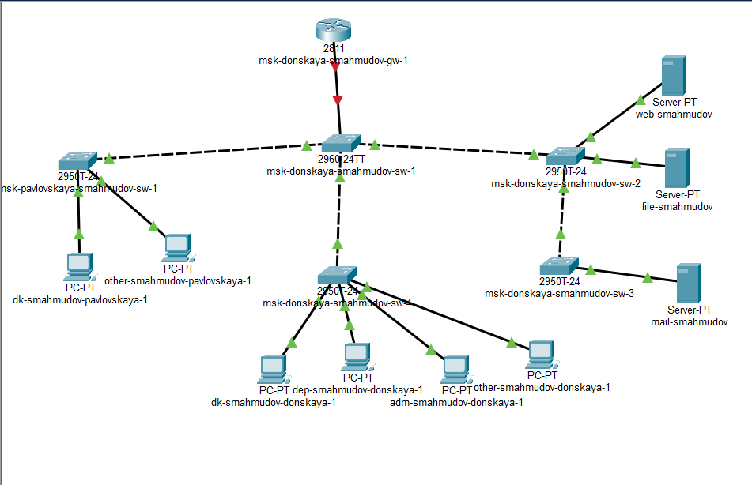

Топология сети с подключённым маршрутизатором Cisco 2811

## Первоначальная настройка маршрутизатора

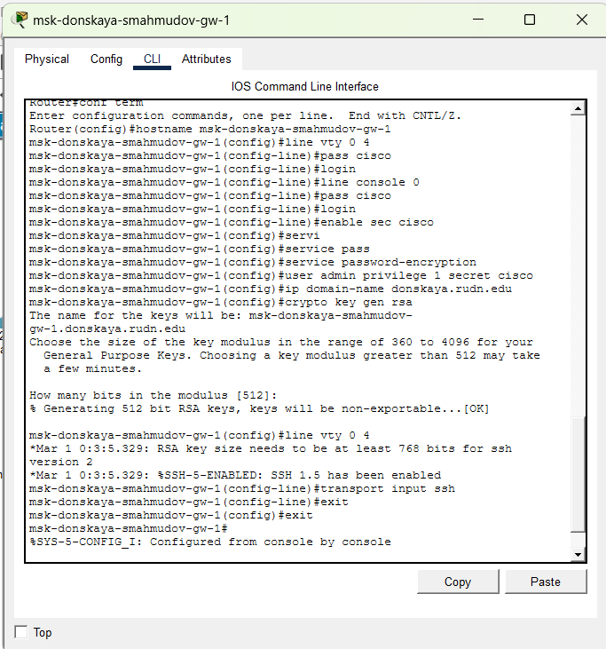

Первоначальная настройка маршрутизатора и включение доступа по SSH

## Настройка подинтерфейсов маршрутизатора

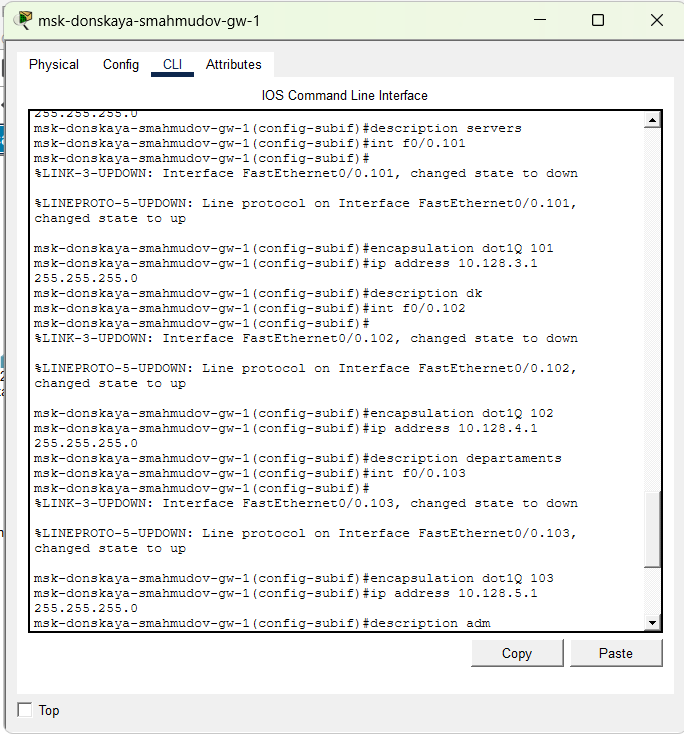

Настройка подинтерфейсов маршрутизатора для межвлановой маршрутизации

## Проверка связности между VLAN

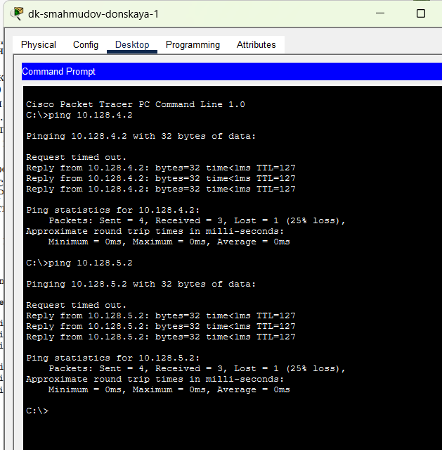

Проверка доступности узлов из разных VLAN с ПК dk-smahmudov-donskaya-1

## Проверка связности с другого ПК

[figure not shown]

Результаты проверки межвлановой связности с ПК other-smahmudov-pavlovskaya-1

## Анализ прохождения ICMP-пакета в Simulation

[figure not shown]

Передвижение пакета ICMP по сети в режиме Simulation

## Структура пакета Ethernet 802.1Q / IP / ICMP

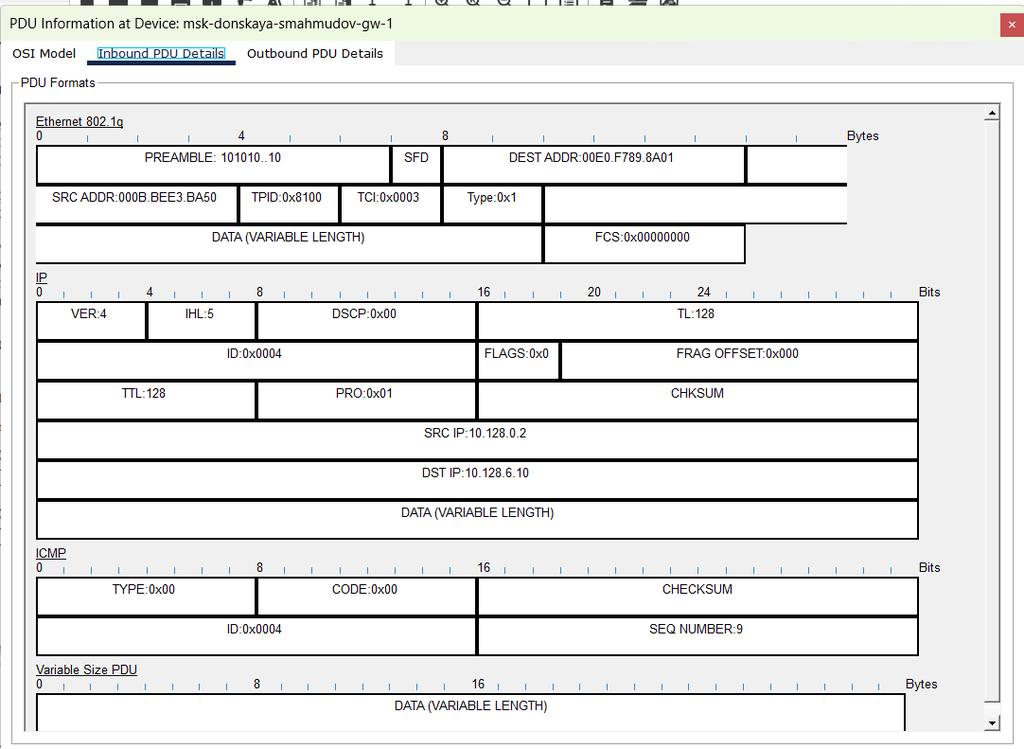

Структура пакета Ethernet 802.1Q, IP и ICMP в окне PDU Information

## Наблюдения по результатам моделирования

- При прохождении через маршрутизатор меняются **MAC-адреса**
- **IP-адреса** источника и назначения сохраняются
- Значение **TTL** уменьшается
- Межвлановый обмен выполняется корректно
- Тегирование **802.1Q** позволяет передавать трафик нескольких VLAN по одному каналу

# Выводы по проделанной работе

## Вывод

- Выполнена настройка межвлановой маршрутизации в сети
- Реализована схема **Router-on-a-Stick**
- Настроен удалённый доступ к маршрутизатору по **SSH**
- Подтверждена связность между узлами разных VLAN
- Изучены инкапсуляция и структура пакета **Ethernet 802.1Q / IP / ICMP**
- Получены практические навыки настройки trunk-порта и подинтерфейсов маршрутизатора